# Synthetic Control Solver Equivalence

Quality-assurance report for the CMake-free implementation

Published

September 23, 2026

## QA conclusion

**TipPASS: numerical equivalence demonstrated**

For the two benchmark designs, the base-R implementation and `Synth` produce the same synthetic-control result within the stated tolerances. Both implementations satisfy the simplex constraints, the base-R result is exactly repeatable, and every acceptance check passes.

The strongest applied test is Proposition 99. Its largest difference between the two synthetic paths is only 0.00267591 cigarette-sales units. The mean post-treatment gap differs by 0.00179100, and pre-treatment MSPE differs by 0.04618%. These differences are numerical solver tolerances, not a change in the estimated counterfactual or substantive conclusion.

## What was compared

The comparison holds the statistical specification fixed and changes only the solver:

1. The treated and donor design matrices are identical.
2. Each predictor and pre-treatment outcome row is divided by its standard deviation across the treated unit and donors.
3. Every standardized row receives equal importance.
4. Donor weights must be non-negative and sum to one.
5. The base-R implementation uses `stats::constrOptim()`; the reference uses `Synth::synth()` with the same fixed predictor-importance vector.

This is the exact objective implemented in the book. The comparison does not mix it with `Synth`’s optional nested search for a different predictor-importance vector. That would be a different estimator specification, not a solver test.

The reference solve used `Synth` 1.1-10 with `Margin.ipop = 1e-6`, `Sigf.ipop = 8`, and `Bound.ipop = 100`. Raising the reference solver’s accuracy above its defaults makes the comparison commensurate with the tight convergence tolerance used by `constrOptim()`.

## Acceptance criteria

The automated runner fails unless every scenario meets all of these conditions:

| Check | Acceptance threshold |
| --- | --- |
| Base-R optimizer convergence | code `0` |
| Donor-weight sum error | less than `1e-10` |
| Minimum donor weight | greater than `-1e-10` |
| Exact-repeat maximum weight difference | less than `1e-12` |
| Relative pre-treatment MSPE difference | less than 1% |
| Maximum synthetic-path difference | less than 0.25 outcome units |
| Mean post-treatment gap difference | less than 0.05 outcome units |

## Results

| Scenario | Donors | Maximum weight difference | Relative pre-MSPE difference | Maximum path difference | Mean post-gap difference | All checks |
| --- | --- | --- | --- | --- | --- | --- |
| Toy mechanics | 6 | 0.000000102290 | 0.00001873% | 0.00000120241 | 0.0000000740579 | PASS |
| Proposition 99 | 38 | 0.000137989 | 0.04618% | 0.00267591 | 0.00179100 | PASS |

The Proposition 99 test includes 38 donors and therefore exercises a materially larger simplex than the six-donor teaching example. The largest donor-weight difference in that test is 0.000137989; the weight RMSE is 0.0000294162.

### Synthetic paths

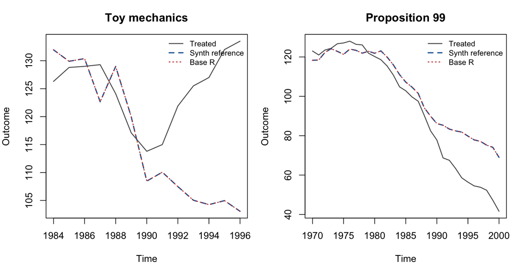

The reference and package-free paths overlap visually. The numerical table is the primary evidence; the plot is a reasonableness check rather than the basis for the verdict.

### Pointwise numerical differences

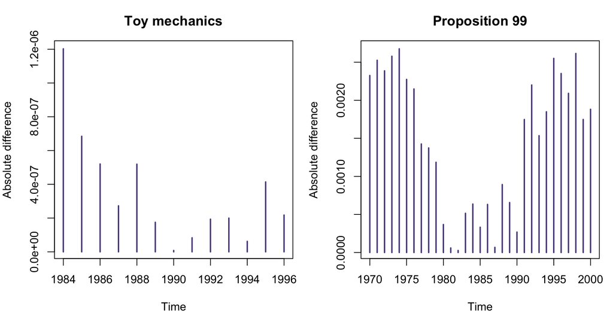

All pointwise differences remain far below the 0.25-unit acceptance threshold.

## Constraint and repeatability checks

| Scenario | Weight-sum error | Minimum weight | Repeat-run maximum difference | Optimizer code | Constraint check | Repeatability check |
| --- | --- | --- | --- | --- | --- | --- |
| Toy mechanics | 0 | 0.000000000000115300 | 0 | 0 | PASS | PASS |
| Proposition 99 | 0 | 0.0000000000000464098 | 0 | 0 | PASS | PASS |

Both base-R fits converged, their weights are non-negative and sum to one, and an immediate repeat produces bit-for-bit identical weights.

## Dependency boundary

The book implementation uses only base R’s `stats` package for optimization. It does not import `Synth`, `optimx`, or `nloptr`. `Synth` and its dependencies exist only in the isolated QA environment used to establish the reference result.

| Tool | Available during QA run |
| --- | --- |
| cmake | No |
| cargo | No |
| rustc | No |

The reference QA run itself completed with CMake, Cargo, and Rust absent. The reference package was installed against the system NLopt library; none of these reference dependencies are included in the book.

## Data integrity and environment

| Input | SHA-256 |
| --- | --- |
| docs/labs/data/synth.data.rds | 47f629894e2fa2f3715a623c81924969dbbc1908078b41ce48d159cb57e6e360 |
| docs/labs/data/smoking.rds | 7b0d79021a4b7566d079ef530b5d93a7bacb143eb172b8d860368f833d93414b |

The test ran under R 4.5.1 on Linux x86_64. Full package and platform details are retained in `results/session-info.txt`.

## Reproduction

The complete test is implemented in `run-equivalence.R`. It writes the machine-readable acceptance results, donor weights, synthetic paths, input hashes, build-tool inventory, serialized comparison objects, and session information to `results/`.

Run it from the repository root in an isolated reference environment containing `Synth`:

```bash
Rscript qa/synthetic-control-equivalence/run-equivalence.R .
```

The command exits with a non-zero status if any acceptance condition fails.

## Scope and limitations

- The tests cover the toy mechanics example and the full Proposition 99 design.
- They validate the estimator specification used in this book: equal importance across standardized predictor and pre-treatment outcome rows.
- They do not claim equivalence for every possible synthetic-control dataset, alternative constraint, or `Synth` optimizer option.
- They do not claim that equal row importance is universally preferable to a nested predictor-importance search. That is a design choice separate from the dependency and solver question tested here.

Within this stated scope, the CMake-free implementation reproduces the reference synthetic controls to substantially tighter tolerances than the acceptance limits and is suitable for the book.